# PA

Author

Kailyn Kragas

[PA 2.1 on GitHub](https://github.com/kailynnk/PA-2.1)

# Titanic Wrangling

**In this practice activity you’ll continue to work with the titanic dataset in ways that flex what you’ve learned about both data wrangling and data visualization.**

```python
import pandas as pd
from plotnine import *
```

```python
data_dir = "https://dlsun.github.io/pods/data/"
titanic_df = pd.read_csv(data_dir + "titanic.csv")
titanic_df.head(5)
```

|  | name | gender | age | class | embarked | country | ticketno | fare | survived |
| --- | --- | --- | --- | --- | --- | --- | --- | --- | --- |
| 0 | Abbing, Mr. Anthony | male | 42.0 | 3rd | S | United States | 5547.0 | 7.11 | 0 |
| 1 | Abbott, Mr. Eugene Joseph | male | 13.0 | 3rd | S | United States | 2673.0 | 20.05 | 0 |
| 2 | Abbott, Mr. Rossmore Edward | male | 16.0 | 3rd | S | United States | 2673.0 | 20.05 | 0 |
| 3 | Abbott, Mrs. Rhoda Mary 'Rosa' | female | 39.0 | 3rd | S | England | 2673.0 | 20.05 | 1 |
| 4 | Abelseth, Miss. Karen Marie | female | 16.0 | 3rd | S | Norway | 348125.0 | 7.13 | 1 |

```python
titanic_df.isna().sum()
```

```
name          0
gender        0
age           2
class         0
embarked      0
country      81
ticketno    891
fare        916
survived      0
dtype: int64
```

## 1. Filter the data to include passengers only. Calculate the joint distribution (cross-tab) between a passenger’s class and where they embarked.**

```python
titanic_df["type"] = titanic_df["class"].map({
    "1st": "passenger",
    "2nd": "passenger",
    "3rd": "passenger",
    "victualling crew": "crew",
    "engineering crew": "crew",
    "deck crew": "crew"
})
```

```python
titanic_passengers = titanic_df[titanic_df["type"] == "passenger"]
```

```python
ctab_counts = pd.crosstab(titanic_passengers["class"], titanic_passengers["embarked"])
ctab_counts
```

| embarked class | B | C | Q | S |
| --- | --- | --- | --- | --- |
| 1st | 3 | 143 | 3 | 175 |
| 2nd | 6 | 26 | 7 | 245 |
| 3rd | 0 | 102 | 113 | 494 |

```python
ctab_norm = pd.crosstab(titanic_passengers["class"], titanic_passengers["embarked"], normalize = True)
ctab_norm
```

| embarked class | B | C | Q | S |
| --- | --- | --- | --- | --- |
| 1st | 0.002278 | 0.108580 | 0.002278 | 0.132878 |
| 2nd | 0.004556 | 0.019742 | 0.005315 | 0.186029 |
| 3rd | 0.000000 | 0.077449 | 0.085801 | 0.375095 |

## 2. Using the joint distribution that calculated above, calculate the following:

- the conditional distribution of their class given where they embarked
- the conditional distribution of where they embarked given their class

Use the conditional distributions that you calculate to answer the following quesitons:

- What proportion of 3rd class passengers embarked at Southampton? 0.70
- What proportion of Southampton passengers were in 3rd class? 0.54

```python
# easier: group by embarked and for each "embarked" group, count the frequency and normalize within group
titanic_passengers.groupby("embarked")["class"].value_counts(normalize = True)
```

```
embarked  class
B         2nd      0.666667
          1st      0.333333
C         1st      0.527675
          3rd      0.376384
          2nd      0.095941
Q         3rd      0.918699
          2nd      0.056911
          1st      0.024390
S         3rd      0.540481
          2nd      0.268053
          1st      0.191466
Name: proportion, dtype: float64
```

```python
# same thing with cross tab
ctab_norm.divide(ctab_norm.sum(axis=0), axis=1)
```

| embarked class | B | C | Q | S |
| --- | --- | --- | --- | --- |
| 1st | 0.333333 | 0.527675 | 0.024390 | 0.191466 |
| 2nd | 0.666667 | 0.095941 | 0.056911 | 0.268053 |
| 3rd | 0.000000 | 0.376384 | 0.918699 | 0.540481 |

```python
titanic_passengers.groupby("class")["embarked"].value_counts(normalize = True)
```

```
class  embarked
1st    S           0.540123
       C           0.441358
       B           0.009259
       Q           0.009259
2nd    S           0.862676
       C           0.091549
       Q           0.024648
       B           0.021127
3rd    S           0.696756
       Q           0.159379
       C           0.143865
Name: proportion, dtype: float64
```

```python
# same thing with cross tab
ctab_norm.divide(ctab_norm.sum(axis=1), axis=0)
```

| embarked class | B | C | Q | S |
| --- | --- | --- | --- | --- |
| 1st | 0.009259 | 0.441358 | 0.009259 | 0.540123 |
| 2nd | 0.021127 | 0.091549 | 0.024648 | 0.862676 |
| 3rd | 0.000000 | 0.143865 | 0.159379 | 0.696756 |

## 3. Make a visualization showing the distribution of a passenger’s class, given where they embarked.

Discuss the pros and cons of using this visualization versus the distributions you calculated before, to answer the previous questions.

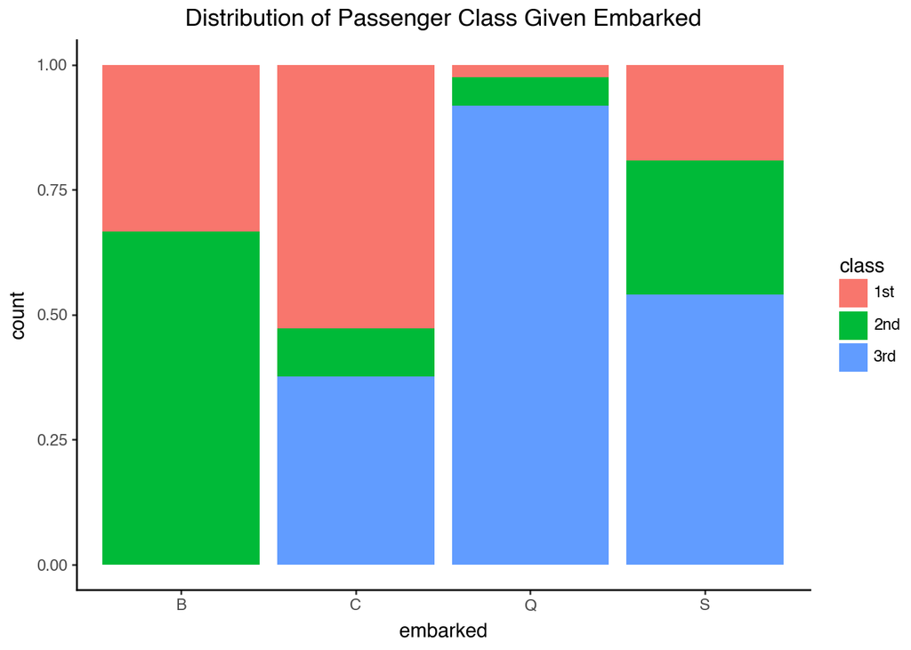

```python
(ggplot(titanic_passengers, aes(x = "embarked", fill = "class")) +
    geom_bar(position='fill') +
    theme_classic() +
    labs(title = "Distribution of Passenger Class Given Embarked"))
```

This visualization makes it easier for users to understand how titanic passenger class is distributed across the different embarked categories. Even without looking at the numbers, they have an idea of what the class proportions are for each embarked group.